# 2. 패키지란? 3. 데이터 처리

##### 데이터 형태 변경

- 데이터는 크게 wide(가로로 긴 형태)와 long(세로로 긴 형태)로 나눌 수 있음
- ggplot에서 그룹 별 그래프를 그리기 위해서는 long 형태로 변형해야 하며, 년/월별 데이터를 보고자 할때는 wide 형태로 변형해야 함
- pivot_longer() 함수는 long 형태, pivot_wider() 함수는 wide 형태로 변형함
- 예제를 위해 2018년~2019년 데이터만 선택

```r
ff_select = ff_mod %>%
  filter(str_sub(Date, 1, 4) %in% c(2018, 2019))

print(ff_select)
```

```
## # A tibble: 24 x 5
##    Date     `Mkt-RF`     SMB      HML      RF
##    <chr>       <dbl>   <dbl>    <dbl>   <dbl>
##  1 2018-01  0.0558   -0.0303 -0.0137  0.0011
##  2 2018-02 -0.0365    0.0026 -0.0119  0.0011
##  3 2018-03 -0.0235    0.0395 -0.00120 0.00120
##  4 2018-04  0.00290   0.0112  0.0054  0.0014
##  5 2018-05  0.0265    0.0523 -0.0316  0.0014
##  6 2018-06  0.00480   0.0118 -0.0238  0.0014
##  7 2018-07  0.0319   -0.0217  0.0043  0.0016
##  8 2018-08  0.0344    0.0115 -0.0408  0.0016
##  9 2018-09  0.000600 -0.0237 -0.013   0.0015
## 10 2018-10 -0.0768   -0.0476  0.0344  0.0019
## # ... with 14 more rows
```

- 해당 데이터를 long(세로로 긴 형태)로 변경
- 기존 gather() 함수가 pivot_longer()로 이름이 변경됨
- 인자는 다음과 같음
  - cols: long 형태로 변형할 컬럼 선택, 마이너스(-)를 입력할 경우 해당 컬럼을 그대로 보존
  - names_to: 컬럼 이름들이 long 형태로 변형될 때, 해당 컬럼의 이름
  - values_to: 각 value들이 long 형태로 변형될 때, 해당 컬럼의 이름
- ggplot을 이용한 시각화에 필수적으로 사용

```r
ff_select %>%
  gather(key = 'Factor', value = 'Return', -Date)
```

```
## # A tibble: 96 x 3
##    Date    Factor    Return
##    <chr>   <chr>      <dbl>
##  1 2018-01 Mkt-RF  0.0558
##  2 2018-02 Mkt-RF -0.0365
##  3 2018-03 Mkt-RF -0.0235
##  4 2018-04 Mkt-RF  0.00290
##  5 2018-05 Mkt-RF  0.0265
##  6 2018-06 Mkt-RF  0.00480
##  7 2018-07 Mkt-RF  0.0319
##  8 2018-08 Mkt-RF  0.0344
##  9 2018-09 Mkt-RF  0.000600
## 10 2018-10 Mkt-RF -0.0768
## # ... with 86 more rows
```

```r
ff_select %>%
  pivot_longer(cols = -Date, names_to = 'factor', values_to = 'return')
```

```
## # A tibble: 96 x 3
##    Date    factor  return
##    <chr>   <chr>    <dbl>
##  1 2018-01 Mkt-RF  0.0558
##  2 2018-01 SMB    -0.0303
##  3 2018-01 HML    -0.0137
##  4 2018-01 RF      0.0011
##  5 2018-02 Mkt-RF -0.0365
##  6 2018-02 SMB     0.0026
##  7 2018-02 HML    -0.0119
##  8 2018-02 RF      0.0011
##  9 2018-03 Mkt-RF -0.0235
## 10 2018-03 SMB     0.0395
## # ... with 86 more rows
```

- 변경 전(wide)과 변경 후(long)을 비교하면 다음과 같다.

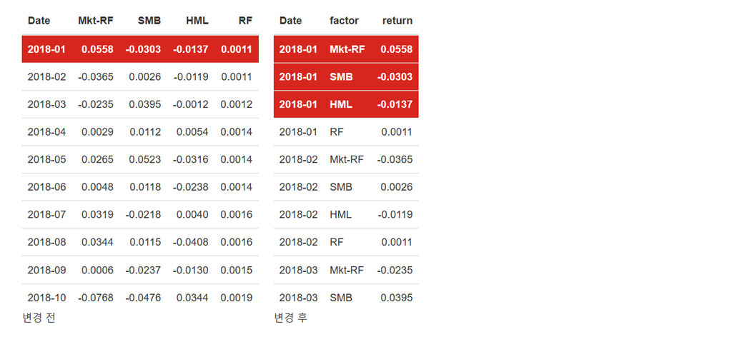

- 위데이터를 다시 변경하고 싶을 때는 다음과 같이 쓰면된다
  - pivot_wider(names_from = ‘factor’,values_from = ‘return’)

```r
f_long = ff_select %>%
  pivot_longer(cols = -Date, names_to = 'factor', values_to = 'return')
f_long
```

```
## # A tibble: 96 x 3
##    Date    factor  return
##    <chr>   <chr>    <dbl>
##  1 2018-01 Mkt-RF  0.0558
##  2 2018-01 SMB    -0.0303
##  3 2018-01 HML    -0.0137
##  4 2018-01 RF      0.0011
##  5 2018-02 Mkt-RF -0.0365
##  6 2018-02 SMB     0.0026
##  7 2018-02 HML    -0.0119
##  8 2018-02 RF      0.0011
##  9 2018-03 Mkt-RF -0.0235
## 10 2018-03 SMB     0.0395
## # ... with 86 more rows
```

```r
f_long %>% pivot_wider(names_from = 'factor',
              values_from = 'return')
```

```
## # A tibble: 24 x 5
##    Date     `Mkt-RF`     SMB      HML      RF
##    <chr>       <dbl>   <dbl>    <dbl>   <dbl>
##  1 2018-01  0.0558   -0.0303 -0.0137  0.0011
##  2 2018-02 -0.0365    0.0026 -0.0119  0.0011
##  3 2018-03 -0.0235    0.0395 -0.00120 0.00120
##  4 2018-04  0.00290   0.0112  0.0054  0.0014
##  5 2018-05  0.0265    0.0523 -0.0316  0.0014
##  6 2018-06  0.00480   0.0118 -0.0238  0.0014
##  7 2018-07  0.0319   -0.0217  0.0043  0.0016
##  8 2018-08  0.0344    0.0115 -0.0408  0.0016
##  9 2018-09  0.000600 -0.0237 -0.013   0.0015
## 10 2018-10 -0.0768   -0.0476  0.0344  0.0019
## # ... with 14 more rows
```

- 이번에는 2018년과 2019년 데이터를 년도와 월별로 wide 형태로 변경
- 기존 spread() 함수가 pivot_wider()로 이름이 변경됨
- 인자는 다음과 같음
  - id_cols: 보존하고자 하는 컬럼
  - names_from: 열 이름으로 들어갈 컬럼
  - values_from: 각 셀의 데이터로 들어갈 컬럼

```r
ff_select %>%
  pivot_longer(cols = -Date, names_to = 'factor',
               values_to = 'return') %>%
  separate(Date, c('Year', 'Month'), sep = '-') %>%
  pivot_wider(id_cols = c(Year, factor),
              names_from = 'Month',
              values_from = 'return')
```

```
## # A tibble: 8 x 14
##   Year  factor    `01`    `02`     `03`     `04`    `05`     `06`    `07`
##   <chr> <chr>    <dbl>   <dbl>    <dbl>    <dbl>   <dbl>    <dbl>   <dbl>
## 1 2018  Mkt-RF  0.0558 -0.0365 -0.0235   0.00290  0.0265  0.00480  0.0319
## 2 2018  SMB    -0.0303  0.0026  0.0395   0.0112   0.0523  0.0118  -0.0217
## 3 2018  HML    -0.0137 -0.0119 -0.00120  0.0054  -0.0316 -0.0238   0.0043
## 4 2018  RF      0.0011  0.0011  0.00120  0.0014   0.0014  0.0014   0.0016
## 5 2019  Mkt-RF  0.0841  0.034   0.011    0.0396  -0.0694  0.0693   0.0119
## 6 2019  SMB     0.0301  0.0206 -0.0313  -0.0168  -0.012   0.0034  -0.0207
## 7 2019  HML    -0.0062 -0.0284 -0.0407   0.0193  -0.0239 -0.0108   0.0014
## 8 2019  RF      0.0021  0.0018  0.0019   0.0021   0.0021  0.0018   0.0019
## # ... with 5 more variables: `08` <dbl>, `09` <dbl>, `10` <dbl>, `11` <dbl>,
## #   `12` <dbl>
```

- 변경 전(long)과 변경 후(wide)을 비교하면 다음과 같다.

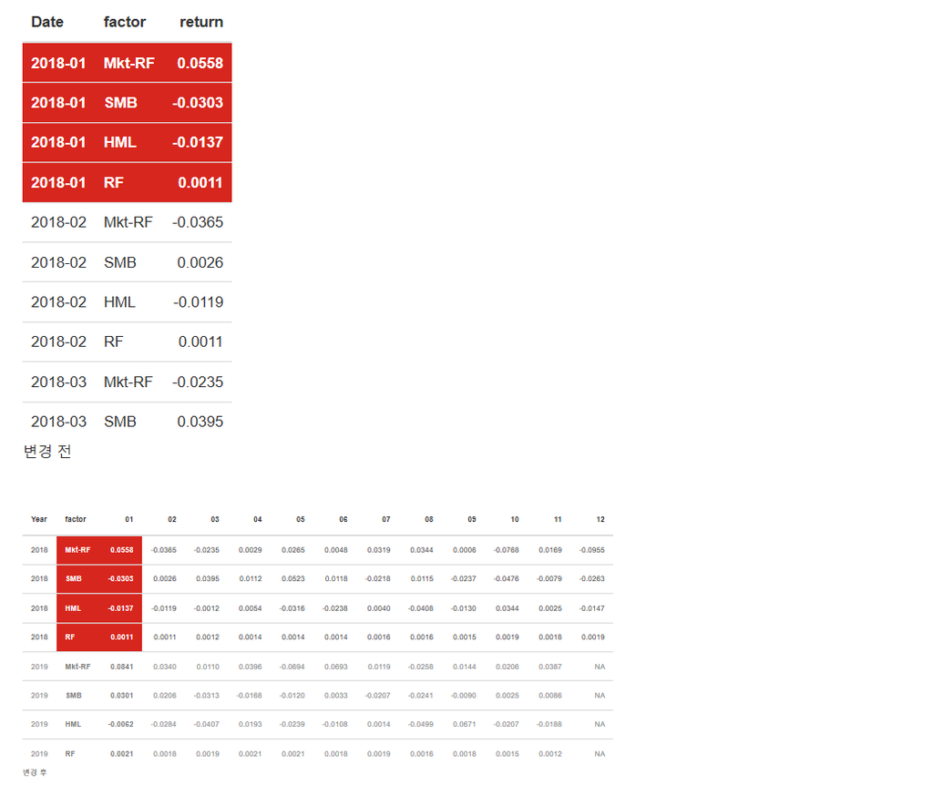

##### 데이터 합치기

- *_join() 함수를 이용해 두 테이블을 하나로 합칠 수 있음

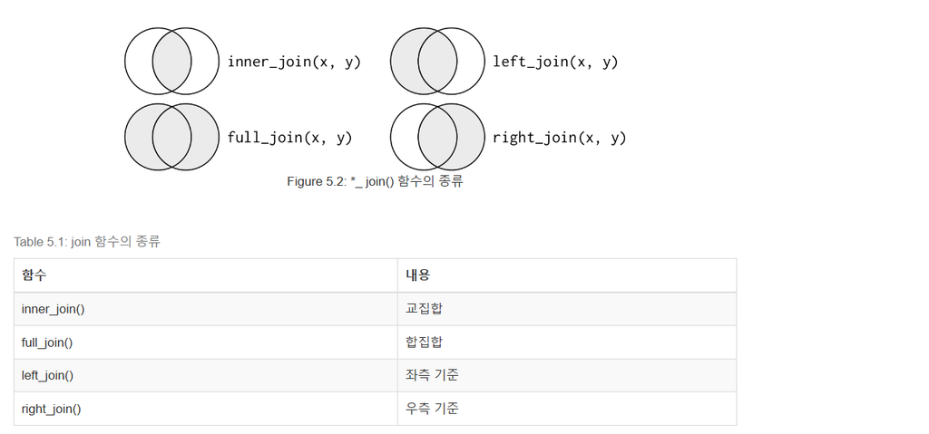

```r
test1 <- data.frame(name=c('서현','민아','유진','다미'), math = c(75, 85,90,70),stringsAsFactors=FALSE)
test2 <- data.frame(name = c('규리','서현','민아','유진','민경'),english = c(80,90,95,70,85),stringsAsFactors=FALSE)
test1
```

```
##   name math
## 1 서현   75
## 2 민아   85
## 3 유진   90
## 4 다미   70
```

```r
test2
```

```
##   name english
## 1 규리      80
## 2 서현      90
## 3 민아      95
## 4 유진      70
## 5 민경      85
```

- inner join
  - inner join은 키(key)를 기준으로 두 테이블에 같이 존재하는 데이터를 추출합니다. 여기에서는 이름(key)을 기준으로 보면 두 테이블에 서현,민아, 유진이가 있네요. ’name’을 기준으로 join하기 위해 by 인자에는 ’name’을 쓰도록 합니다. inner join은 집합에서 교집합의 개념과 동일합니다. dplyr패키지에서 inner_join 함수를 사용합니다.

```r
inner_join(test1,test2,by='name')
```

```
##   name math english
## 1 서현   75      90
## 2 민아   85      95
## 3 유진   90      70
```

- full (outer) join
  - full join은 키(key)를 기준으로 두 테이블에 존재하는 모든 데이터를 뽑아내어 병합합니다. 여기에서는 이름(key)을 기준으로 보면 두 테이블에 서현, 민아, 유진, 다미, 규리 민경이가 있네요. 수학 테이블에는 규리와, 민경이의 데이터가 존재하지 않습니다. 반면 영어 테이블에는 다미의 데이터가 존재하지 않습니다. inner join 과 다르게 full join 은 각 테이블 모든 데이터를 병합합니다.집합에서는 합집합의 개념과 동일합니다. 각 테이블에 없는 학생은 결측값(NA)로 반환됩니다. dplyr패키지에서 full_join 함수를 사용합니다.

```r
full_join(test1,test2,by='name')
```

```
##   name math english
## 1 서현   75      90
## 2 민아   85      95
## 3 유진   90      70
## 4 다미   70      NA
## 5 규리   NA      80
## 6 민경   NA      85
```

- left join
  - left join은 왼쪽에 있는 테이블의 key을 기준으로 병합합니다. 왼쪽 테이블을 수학점수 테이블로 놓고, 오른쪽 테이블을 영어점수 테이블로 세팅해보겠습니다. 수학점수 테이블에는 서현, 민아, 유진, 다미가 있습니다. 이때 오른쪽 테이블(영어점수 테이블)과 병합합니다. dplyr패키지에서 left_join 함수를 사용합니다.

```r
left_join(test1,test2,by='name')
```

```
##   name math english
## 1 서현   75      90
## 2 민아   85      95
## 3 유진   90      70
## 4 다미   70      NA
```

- right join
  - left join과 반대로 right join 은 영어점수 테이블(오른쪽 테이블)에 있는 데이터를 반환합니다. 규리와 민경이는 수학점수 테이블에 존재하지 않으므로 결측값(NA)를 반환했습니다. dplyr패키지에서 right_join 함수를 사용합니다.

```r
right_join(test1,test2,by='name')
```

```
##   name math english
## 1 규리   NA      80
## 2 서현   75      90
## 3 민아   85      95
## 4 유진   90      70
## 5 민경   NA      85
```

- quantmod 패키지를 이용해 Yahoo API를 통해 애플 주식의 주가(AAPL)를 다운로드
- 월말에 해당하는 주가만 뽑아, 월간 수익률을 계산

```r
library(quantmod)
library(PerformanceAnalytics)
price = getSymbols('AAPL', from = '1900-01-01', auto.assign = FALSE) %>% Ad()
```

[output not shown]

```r
head(price)
```

```
##            AAPL.Adjusted
## 1980-12-12      0.405683
## 1980-12-15      0.384517
## 1980-12-16      0.356296
## 1980-12-17      0.365115
## 1980-12-18      0.375698
## 1980-12-19      0.398628
```

```r
tail(price)
```

```
##            AAPL.Adjusted
## 2020-05-01      288.2896
## 2020-05-04      292.3686
## 2020-05-05      296.7567
## 2020-05-06      299.8184
## 2020-05-07      302.9200
## 2020-05-08      310.1300
```

```r
library(ggplot2)
ep = endpoints(price)

ret_mod = price[ep] %>% Return.calculate %>%
  set_colnames('AAPL') %>%
  fortify() %>%
  mutate(Index = str_sub(Index, 1, 7),
         AAPL = round(AAPL, 4))

head(ret_mod)
```

```
##     Index    AAPL
## 1 1980-12      NA
## 2 1981-01 -0.1722
## 3 1981-02 -0.0619
## 4 1981-03 -0.0755
## 5 1981-04  0.1582
## 6 1981-05  0.1674
```

- 3 Factor 테이블(ff_mod)의 Date와 애플 수익률(ret_mod)의 Index가 매칭되므로, 이를 이용해 테이블을 합쳐줌

```r
df = left_join(ff_mod, ret_mod,
                         by = c('Date' = 'Index')) %>% na.omit()

print(df)
```

```
## # A tibble: 471 x 6
##    Date    `Mkt-RF`     SMB     HML     RF    AAPL
##    <chr>      <dbl>   <dbl>   <dbl>  <dbl>   <dbl>
##  1 1981-01 -0.0504   0.03    0.0684 0.0104 -0.172
##  2 1981-02  0.00570 -0.0031  0.0097 0.0107 -0.0619
##  3 1981-03  0.0356   0.0358  0.0067 0.0121 -0.0755
##  4 1981-04 -0.0211   0.0442  0.0226 0.0108  0.158
##  5 1981-05  0.0011   0.02   -0.0043 0.0115  0.167
##  6 1981-06 -0.0236  -0.0085  0.0513 0.0135 -0.215
##  7 1981-07 -0.0154  -0.0218 -0.0066 0.0124 -0.0385
##  8 1981-08 -0.0704  -0.0195  0.0484 0.0128 -0.195
##  9 1981-09 -0.0717  -0.0266  0.052  0.0124 -0.242
## 10 1981-10  0.0492   0.0213 -0.0421 0.0121  0.312
## # ... with 461 more rows
```

### 3.3 탐색적 데이터 분석

- Exploratory Data Analysis
- 데이터가 어떠한 특성을 가지고 있는지에 대한 분석 및 시각화 과정
- 데이터 분석에는 dplyr, 시각화에는 ggplot2 패키지가 사용됨

#### 3.3.1 rvest/dplyr를 활용

- 다음 함수가 대표적으로 사용됨
  - select(): 원하는 컬럼 선택
  - filter(): 조건에 맞는 행 선택
  - mutate(): 열 생성 및 데이터 변형
  - group_by(): 그룹별로 데이터를 묶기
- 이 외에도 rvest/dplyr 패키지에는 데이터 분석을 위한 대부분의 함수가 포함되어 있음

##### Titanic 예제로 데이터 처리

```r
library(rvest)
library(dplyr)
Titanic = read.csv('Titanic.csv',stringsAsFactors = F)
Titanic %>% head()
```

```
##   pclass survived                                            name    sex
## 1      1        1                   Allen, Miss. Elisabeth Walton female
## 2      1        1                  Allison, Master. Hudson Trevor   male
## 3      1        0                    Allison, Miss. Helen Loraine female
## 4      1        0            Allison, Mr. Hudson Joshua Creighton   male
## 5      1        0 Allison, Mrs. Hudson J C (Bessie Waldo Daniels) female
## 6      1        1                             Anderson, Mr. Harry   male
##       age sibsp parch ticket     fare   cabin embarked boat body
## 1 29.0000     0     0  24160 211.3375      B5        S    2   NA
## 2  0.9167     1     2 113781 151.5500 C22 C26        S   11   NA
## 3  2.0000     1     2 113781 151.5500 C22 C26        S        NA
## 4 30.0000     1     2 113781 151.5500 C22 C26        S       135
## 5 25.0000     1     2 113781 151.5500 C22 C26        S        NA
## 6 48.0000     0     0  19952  26.5500     E12        S    3   NA
##                         home.dest
## 1                    St Louis, MO
## 2 Montreal, PQ / Chesterville, ON
## 3 Montreal, PQ / Chesterville, ON
## 4 Montreal, PQ / Chesterville, ON
## 5 Montreal, PQ / Chesterville, ON
## 6                    New York, NY
```

##### `match()`를 활용하여 데이터의 변수 위치 확인

```r
names(Titanic)
```

```
##  [1] "pclass"    "survived"  "name"      "sex"       "age"       "sibsp"
##  [7] "parch"     "ticket"    "fare"      "cabin"     "embarked"  "boat"
## [13] "body"      "home.dest"
```

```r
#names에서 "pclass","survived","ticket"의 위치
match(c("pclass","survived","ticket"),  names(Titanic))
```

```
## [1] 1 2 8
```

- 데이터를 추출하는 방법으로는 여러가지가 있다
  - 아래 코드 모두 동일한 결과를 갖는다

```r
Titanic[, match(c("pclass","survived","ticket"),  names(Titanic)) ] %>% head()
```

```
##   pclass survived ticket
## 1      1        1  24160
## 2      1        1 113781
## 3      1        0 113781
## 4      1        0 113781
## 5      1        0 113781
## 6      1        1  19952
```

```r
Titanic[,c("pclass","survived","ticket") ] %>% head()
```

```
##   pclass survived ticket
## 1      1        1  24160
## 2      1        1 113781
## 3      1        0 113781
## 4      1        0 113781
## 5      1        0 113781
## 6      1        1  19952
```

```r
Titanic[c("pclass","survived","ticket")] %>% head()
```

```
##   pclass survived ticket
## 1      1        1  24160
## 2      1        1 113781
## 3      1        0 113781
## 4      1        0 113781
## 5      1        0 113781
## 6      1        1  19952
```

##### 원하는 데이터 추출하기

- Titanic 데이터에서 생존한 사람 survived 변수가 1을 가진 사람만 데이터 추출해보자
  - 위치를 확인하여 대괄호[] 안에 넣어 인덱싱을 한다
  - survived 변수가 1을 가진 행 추출

```r
(Titanic$survived == 1) %>% head() #T/F 형태로 나옴
```

```
## [1]  TRUE  TRUE FALSE FALSE FALSE  TRUE
```

```r
Titanic[Titanic$survived == 1, ] %>% head()
```

```
##    pclass survived                                              name    sex
## 1       1        1                     Allen, Miss. Elisabeth Walton female
## 2       1        1                    Allison, Master. Hudson Trevor   male
## 6       1        1                               Anderson, Mr. Harry   male
## 7       1        1                 Andrews, Miss. Kornelia Theodosia female
## 9       1        1     Appleton, Mrs. Edward Dale (Charlotte Lamson) female
## 12      1        1 Astor, Mrs. John Jacob (Madeleine Talmadge Force) female
##        age sibsp parch   ticket     fare   cabin embarked boat body
## 1  29.0000     0     0    24160 211.3375      B5        S    2   NA
## 2   0.9167     1     2   113781 151.5500 C22 C26        S   11   NA
## 6  48.0000     0     0    19952  26.5500     E12        S    3   NA
## 7  63.0000     1     0    13502  77.9583      D7        S   10   NA
## 9  53.0000     2     0    11769  51.4792    C101        S    D   NA
## 12 18.0000     1     0 PC 17757 227.5250 C62 C64        C    4   NA
##                          home.dest
## 1                     St Louis, MO
## 2  Montreal, PQ / Chesterville, ON
## 6                     New York, NY
## 7                       Hudson, NY
## 9              Bayside, Queens, NY
## 12                    New York, NY
```

```r
#-> 같은 결과 head(Titanic[Titanic$survived == 1, ])
```

##### `which()` 함수를 활용하여 데이터 추출하기

```r
Titanic[Titanic$age<20, c("age","survived","ticket")] %>% head() #NA 포함
```

```
##          age survived   ticket
## 2     0.9167        1   113781
## 3     2.0000        0   113781
## 12   18.0000        1 PC 17757
## NA        NA       NA     <NA>
## 28   19.0000        1    11967
## NA.1      NA       NA     <NA>
```

```r
Titanic[which(Titanic$age<20), c("age","survived","ticket")] %>% head() #NA 제외
```

```
##        age survived   ticket
## 2   0.9167        1   113781
## 3   2.0000        0   113781
## 12 18.0000        1 PC 17757
## 28 19.0000        1    11967
## 54 17.0000        0   113059
## 55 11.0000        1   113760
```

```r
which(Titanic$age<20)
```

```
##   [1]    2    3   12   28   54   55   56   93   95  115  138  160  188  194  196
##  [16]  198  199  217  229  230  250  251  271  274  290  296  327  332  338  340
##  [31]  341  342  345  351  360  365  378  386  387  391  395  396  399  406  409
##  [46]  417  428  431  435  446  459  479  480  483  493  502  504  511  514  515
##  [61]  516  519  531  535  541  542  549  550  553  559  569  570  583  588  589
##  [76]  591  592  602  603  605  608  612  613  620  622  623  624  625  626  628
##  [91]  629  637  640  641  642  643  644  651  654  658  659  660  662  666  670
## [106]  677  679  680  693  695  696  699  701  702  710  718  720  732  734  735
## [121]  738  739  741  745  748  756  762  763  764  772  773  778  787  788  792
## [136]  793  795  800  808  810  811  819  821  826  827  828  829  830  831  840
## [151]  842  856  860  867  886  895  896  899  911  917  920  935  938  939 1008
## [166] 1012 1026 1046 1048 1049 1051 1057 1058 1061 1083 1094 1097 1098 1099 1100
## [181] 1102 1103 1104 1105 1106 1109 1112 1113 1128 1131 1134 1142 1143 1144 1145
## [196] 1146 1157 1158 1162 1172 1188 1190 1206 1207 1208 1209 1210 1218 1227 1231
## [211] 1233 1237 1241 1245 1257 1258 1261 1264 1266 1274 1276 1280 1289 1301 1305
```

##### `unique() table()` 변수의 값들 집계하기

- unique()함수는 데이터의 값이 어떤것들이 있는지 확인
- table()함수는 데이터의 값들의 각각의 갯수 확인
  - NA는 집계되지않는다

```r
Titanic$survived %>% unique()
```

```
## [1]  1  0 NA
```

```r
t = table(Titanic$survived)
t
```

```
##
##   0   1
## 809 500
```

##### `is.na()` NA값 처리

- NA값에 사칙연산을 해도 NA가된다
- is.na()함수를 통해 NA값을 True/False로 반환
  - !is.na()를 하면 NA가 아닌 값들만 추출할 수 있다

```r
Titanic_ex <- Titanic
# 달러 -> 원화
Titanic_ex$fare <- Titanic_ex$fare * 1227
#NA * 1227 = NA
is.na(Titanic_ex$fare) %>% head() #True/False로 나옴
```

```
## [1] FALSE FALSE FALSE FALSE FALSE FALSE
```

```r
nrow(Titanic_ex)
```

```
## [1] 1310
```

```r
Titanic_ex <- Titanic_ex[!is.na(Titanic_ex$fare),]
nrow(Titanic_ex) #2명 삭제됨
```

```
## [1] 1308
```

##### `mean() by() aggregate()`함수 사용 평균 구하기

- sex별 age 평균구하기
  - 1. mean을 사용하여 각각의 데이터 선택 후 평균구하는 방법
  - 2. by를 사용하여 그룹을 나누어 평균을 구하는 방법
  - 3. aggregate를 사용하여 그룹을 나누어 평균을 구하는 방법(sex = ""일경우는 나오지않는다)
- na.rm = T 을 사용하여 결측값을 제거
- 이상값을 제거 후 mean값을 구하고 싶을때 trim옵션을 사용한다

```r
Titanic$sex %>% unique()
```

```
## [1] "female" "male"   ""
```

```r
mean( Titanic$age[Titanic$sex == "female"], na.rm = T )
```

```
## [1] 28.68707
```

```r
mean( Titanic$age[Titanic$sex == "male"], na.rm = T )
```

```
## [1] 30.58523
```

```r
mean( Titanic$age[Titanic$sex == ""], na.rm = T )
```

```
## [1] NaN
```

```r
by( data = Titanic$age, INDICES =  Titanic$sex,
    FUN  = mean, na.rm = TRUE)
```

```
## Titanic$sex:
## [1] NaN
## ------------------------------------------------------------
## Titanic$sex: female
## [1] 28.68707
## ------------------------------------------------------------
## Titanic$sex: male
## [1] 30.58523
```

```r
aggregate(formula = age ~ sex, data = Titanic,
          FUN = mean, na.rm = TRUE)
```

```
##      sex      age
## 1 female 28.68707
## 2   male 30.58523
```

```r
aggregate(formula = age ~ sex,
               data = Titanic, FUN = mean, na.rm = TRUE,trim = 0.05) #trim 양옆 각각 5%씩 빼고
```

```
##      sex      age
## 1 female 28.41714
## 2   male 30.27694
```

##### `filter() select() summarize()`함수 사용법

- filter()를 통해 원하는 데이터를 추출할 수 있음
- select()을 통해 원하는 변수만을 선택
- summarize()를통해 mean,max,min등의 값을 구할 수 있음

```r
Titanic %>%
  filter(Titanic$sex=="male") %>%
  select(age,sex) %>%
  summarize(mean_age = mean(age, na.rm = TRUE))
```

```
##   mean_age
## 1 30.58523
```

##### `table()`함수 사용법

- 변수 하나만을 적용하면 하나의 집계표가 나오지만 두개의 변수를 적용하면 교차테이블을 만들 수 있다

```r
Titanic %>% head()
```

```
##   pclass survived                                            name    sex
## 1      1        1                   Allen, Miss. Elisabeth Walton female
## 2      1        1                  Allison, Master. Hudson Trevor   male
## 3      1        0                    Allison, Miss. Helen Loraine female
## 4      1        0            Allison, Mr. Hudson Joshua Creighton   male
## 5      1        0 Allison, Mrs. Hudson J C (Bessie Waldo Daniels) female
## 6      1        1                             Anderson, Mr. Harry   male
##       age sibsp parch ticket     fare   cabin embarked boat body
## 1 29.0000     0     0  24160 211.3375      B5        S    2   NA
## 2  0.9167     1     2 113781 151.5500 C22 C26        S   11   NA
## 3  2.0000     1     2 113781 151.5500 C22 C26        S        NA
## 4 30.0000     1     2 113781 151.5500 C22 C26        S       135
## 5 25.0000     1     2 113781 151.5500 C22 C26        S        NA
## 6 48.0000     0     0  19952  26.5500     E12        S    3   NA
##                         home.dest
## 1                    St Louis, MO
## 2 Montreal, PQ / Chesterville, ON
## 3 Montreal, PQ / Chesterville, ON
## 4 Montreal, PQ / Chesterville, ON
## 5 Montreal, PQ / Chesterville, ON
## 6                    New York, NY
```

```r
table(Titanic$sex)
```

```
##
##        female   male
##      1    466    843
```

```r
table(Titanic$sex, Titanic$survived) #교차 테이블 작성
```

```
##
##            0   1
##            0   0
##   female 127 339
##   male   682 161
```

##### 데이터 정렬하기

- order(),arrange() : 순서대로 정렬 default = 오름차순

```r
Titanic[order(Titanic$name),] %>% head(10)#name 정렬
```

```
##      pclass survived                                     name    sex age sibsp
## 1310     NA       NA                                                  NA    NA
## 601       3        0                      Abbing, Mr. Anthony   male  42     0
## 602       3        0            Abbott, Master. Eugene Joseph   male  13     0
## 603       3        0              Abbott, Mr. Rossmore Edward   male  16     1
## 604       3        1         Abbott, Mrs. Stanton (Rosa Hunt) female  35     1
## 605       3        1              Abelseth, Miss. Karen Marie female  16     0
## 606       3        1            Abelseth, Mr. Olaus Jorgensen   male  25     0
## 324       2        0                      Abelson, Mr. Samuel   male  30     1
## 325       2        1    Abelson, Mrs. Samuel (Hannah Wizosky) female  28     1
## 607       3        1 Abrahamsson, Mr. Abraham August Johannes   male  20     0
##      parch           ticket   fare cabin embarked boat body
## 1310    NA                      NA                       NA
## 601      0        C.A. 5547  7.550              S        NA
## 602      2        C.A. 2673 20.250              S        NA
```

[output cut: 18 more lines]

```r
tmp <- Titanic
tmp <- tmp[order(tmp$age, decreasing = TRUE),]
tmp <- tmp[order(tmp$name),]

#정렬 오름차순
Titanic %>% arrange(name, age) %>% head()
```

```
##   pclass survived                             name    sex age sibsp parch
## 1     NA       NA                                          NA    NA    NA
## 2      3        0              Abbing, Mr. Anthony   male  42     0     0
## 3      3        0    Abbott, Master. Eugene Joseph   male  13     0     2
## 4      3        0      Abbott, Mr. Rossmore Edward   male  16     1     1
## 5      3        1 Abbott, Mrs. Stanton (Rosa Hunt) female  35     1     1
## 6      3        1      Abelseth, Miss. Karen Marie female  16     0     0
##      ticket  fare cabin embarked boat body              home.dest
## 1              NA                       NA
## 2 C.A. 5547  7.55              S        NA
## 3 C.A. 2673 20.25              S        NA    East Providence, RI
## 4 C.A. 2673 20.25              S       190    East Providence, RI
## 5 C.A. 2673 20.25              S    A   NA    East Providence, RI
## 6    348125  7.65              S   16   NA Norway Los Angeles, CA
```

```r
#정렬 내림차순
Titanic %>% arrange(desc(name), age) %>% head()
```

```
##   pclass survived                                   name    sex  age sibsp
## 1      3        0                     Zimmerman, Mr. Leo   male 29.0     0
## 2      3        0                    Zakarian, Mr. Ortin   male 27.0     0
## 3      3        0              Zakarian, Mr. Mapriededer   male 26.5     0
## 4      3        0                  Zabour, Miss. Thamine female   NA     1
## 5      3        0                   Zabour, Miss. Hileni female 14.5     1
## 6      2        0 Yrois, Miss. Henriette ("Mrs Harbeck") female 24.0     0
##   parch ticket    fare cabin embarked boat body home.dest
## 1     0 315082  7.8750              S        NA
## 2     0   2670  7.2250              C        NA
## 3     0   2656  7.2250              C       304
## 4     0   2665 14.4542              C        NA
## 5     0   2665 14.4542              C       328
## 6     0 248747 13.0000              S        NA     Paris
```

##### `mutate()` 파생변수 생성

```r
Titanic_ex <- Titanic %>%
  filter(!is.na(Titanic$fare)) %>%
  mutate(won = fare * 1227)
head(Titanic_ex)
```

```
##   pclass survived                                            name    sex
## 1      1        1                   Allen, Miss. Elisabeth Walton female
## 2      1        1                  Allison, Master. Hudson Trevor   male
## 3      1        0                    Allison, Miss. Helen Loraine female
## 4      1        0            Allison, Mr. Hudson Joshua Creighton   male
## 5      1        0 Allison, Mrs. Hudson J C (Bessie Waldo Daniels) female
## 6      1        1                             Anderson, Mr. Harry   male
##       age sibsp parch ticket     fare   cabin embarked boat body
## 1 29.0000     0     0  24160 211.3375      B5        S    2   NA
## 2  0.9167     1     2 113781 151.5500 C22 C26        S   11   NA
## 3  2.0000     1     2 113781 151.5500 C22 C26        S        NA
## 4 30.0000     1     2 113781 151.5500 C22 C26        S       135
## 5 25.0000     1     2 113781 151.5500 C22 C26        S        NA
## 6 48.0000     0     0  19952  26.5500     E12        S    3   NA
##                         home.dest       won
## 1                    St Louis, MO 259311.11
## 2 Montreal, PQ / Chesterville, ON 185951.85
## 3 Montreal, PQ / Chesterville, ON 185951.85
## 4 Montreal, PQ / Chesterville, ON 185951.85
## 5 Montreal, PQ / Chesterville, ON 185951.85
## 6                    New York, NY  32576.85
```

##### `group_by()` 그룹핑

- group_by()을 통해 그룹핑을 한다
- tally()는 table()역할과 같다
  - table()이 결과가 더 깔끔하게 나옴

```r
Titanic %>%
  group_by(sex) %>%
  summarize(mean_age = mean(age, na.rm = TRUE))
```

```
## # A tibble: 3 x 2
##   sex      mean_age
##   <chr>       <dbl>
## 1 ""          NaN
## 2 "female"     28.7
## 3 "male"       30.6
```

```r
Titanic %>%
  filter(!is.na(age)) %>%
  group_by(sex, survived) %>%
  summarize(mean_age = mean(age),
            var_age = var(age),
            min_age = min(age),
            max_age = max(age)) %>%
  print(n = 5)
```

```
## # A tibble: 4 x 6
## # Groups:   sex [2]
##   sex    survived mean_age var_age min_age max_age
##   <chr>     <int>    <dbl>   <dbl>   <dbl>   <dbl>
## 1 female        0     25.3    182.   1          63
## 2 female        1     29.8    218.   0.167      76
## 3 male          0     31.5    190.   0.333      74
## 4 male          1     27.0    242.   0.417      80
```

```r
# -----------------------------------
#table(Titanic$sex)
Titanic %>%
  group_by(sex) %>%
  tally()
```

```
## # A tibble: 3 x 2
##   sex          n
##   <chr>    <int>
## 1 ""           1
## 2 "female"   466
## 3 "male"     843
```

```r
#table(Titanic$survived,Titanic$sex)
Titanic %>%
  group_by(survived, sex) %>%
  tally()
```

```
## # A tibble: 5 x 3
## # Groups:   survived [3]
##   survived sex          n
##      <int> <chr>    <int>
## 1        0 "female"   127
## 2        0 "male"     682
## 3        1 "female"   339
## 4        1 "male"     161
## 5       NA ""           1
```

##### `melt() dcast()`함수 사용하여 데이터 형태 바꾸기

- melt() :열 이름을 variable로 해당 열의 행값들을value값으로 바꾸어준다
- dcast(): melt와 반대의 역할

```r
library(reshape2)
airquality %>% head(3)
```

```
##   Ozone Solar.R Wind Temp Month Day
## 1    41     190  7.4   67     5   1
## 2    36     118  8.0   72     5   2
## 3    12     149 12.6   74     5   3
```

```r
data = melt(airquality, id.vars= c("Month","Day"))
data %>% head()
```

```
##   Month Day variable value
## 1     5   1    Ozone    41
## 2     5   2    Ozone    36
## 3     5   3    Ozone    12
## 4     5   4    Ozone    18
## 5     5   5    Ozone    NA
## 6     5   6    Ozone    28
```

```r
dcast(data, Month + Day ~ variable,
      value.var ="value") %>% head()
```

```
##   Month Day Ozone Solar.R Wind Temp
## 1     5   1    41     190  7.4   67
## 2     5   2    36     118  8.0   72
## 3     5   3    12     149 12.6   74
## 4     5   4    18     313 11.5   62
## 5     5   5    NA      NA 14.3   56
## 6     5   6    28      NA 14.9   66
```